# First Week Bootcamp

Matt Moocarme

May 28, 2016

The goal is to understand if there are any differences in opinion between Germans and Americans about the recent trade agreement.

The data comes from the Pew reasearch center, which can be found at ‘http://www.pewglobal.org/category/datasets/?download=31944’

We can look at some of the column names of the dataset:

```
## [1] "rid" "Q1"  "Q2a" "Q2c" "Q2d" "Q2e"
```

Unfortunately the column names aren’t indicative of the questions, this could be because to save sapce in the colmn name, i.e., ‘Q1’, ‘Q2’, are used instead the actual questions. The actual questions may be an attribute, so we can check that

```r
#dim(trade)
attr <- attributes(trade)
#str(attr)
labels <- attr$variable.labels
```

We can check out examples of the specific questions

```r
labels[2]
```

```
##                                                                                                                                                                                                                 Q1
## "Q1 What do you think about growing trade between [GERMANY: Germany / U.S.: the U.S.] and other countries �do you think it is a very good thing, somewhat good, somewhat bad or a very bad thing for our country?"
```

```r
# Other ways to check out a question
labels[which(names(trade) == 'Q1')]
labels[names(trade) == 'Q1']
```

### Sentiment Analysis

#### Sentiment by Country

How do the Americans vs Germans feel about the trade deal

Now we have the data we are going to tidy it up so that we are not working with any extraneous data. The goal is to look at what is the most frequent response. The relevant variables we are interested in a the country, questions, and answers.

```r
library(dplyr)
library(tidyr)
# select relevant columns
trade_senti <- trade %>% select(country, contains("Q"))
# reshape data so question and answwer are their own column
trade_tidy <- trade_senti %>% gather(Question, Answer, -country)

trade_freq <- trade_tidy %>% group_by(country, Question, Answer) %>% summarise(Total.count = n()) %>%
    mutate(freq.answer = 100 * (Total.count/sum(Total.count)))

ordered_trade_freq <- trade_freq %>% arrange(country, Question, desc(Total.count))
max_answer <- ordered_trade_freq %>% group_by(country, Question) %>% filter(Total.count ==
    max(Total.count))

head(max_answer)
```

```
## Source: local data frame [6 x 5]
## Groups: country, Question [6]
##
##         country Question        Answer Total.count freq.answer
##          (fctr)    (chr)         (chr)       (int)       (dbl)
## 1 United States       Q1 Somewhat good         451    45.00998
## 2 United States      Q10            NA        1002   100.00000
## 3 United States      Q2a Somewhat good         497    49.60080
## 4 United States      Q2b            NA        1002   100.00000
## 5 United States      Q2c Somewhat good         363    36.22754
## 6 United States      Q2d Somewhat good         462    46.10778
```

Apart from some NA values floating around it is nice and tidy!

Okay, now let’s plot some things

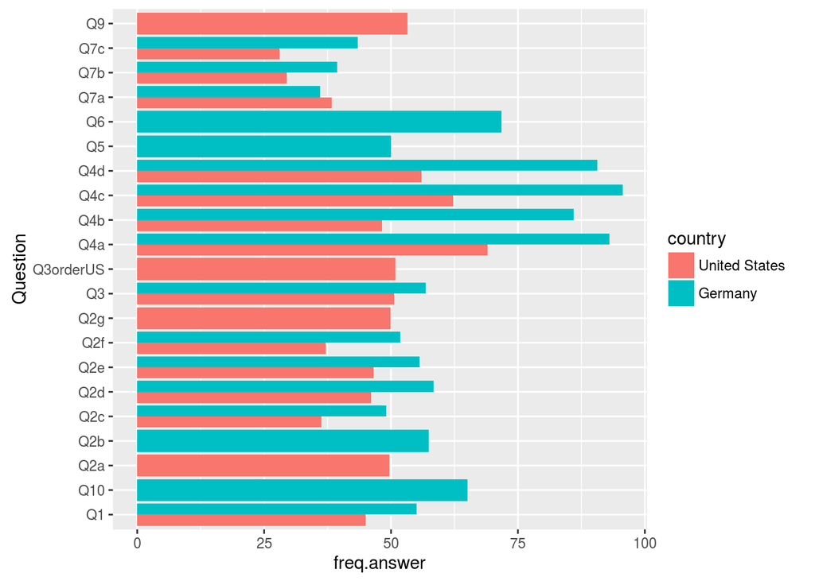

```r
library(ggplot2)
my_plot <-ggplot(data = na.omit(max_answer), aes(x = Question, y =freq.answer, fill= country)) + geom_bar(stat = 'identity', position = 'dodge')
my_plot + coord_flip()
```

Now we will do the same, but only looking at question 1, the main difference here is that we only select question one at the beginning og the tidying process

```r
new_data <- trade %>% select(country, Q1) %>% gather(Question, Answer, -country) %>% group_by(Question, country, Answer) %>% summarise(Total.count = n()) %>% mutate(freq = Total.count/sum(Total.count)) %>% filter(Answer == 'Very good')
```

And now we plot

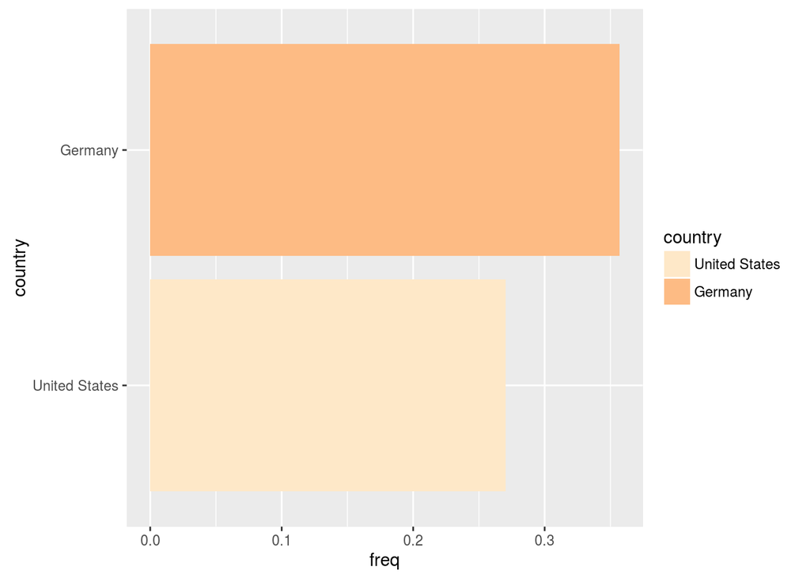

```r
myQ1_plot <- ggplot(data= na.omit(new_data), aes(x = country, y = freq, fill= country))  + geom_bar(stat = 'identity', position = 'dodge')
myQ1_plot + coord_flip()+scale_fill_brewer(palette="OrRd")
```

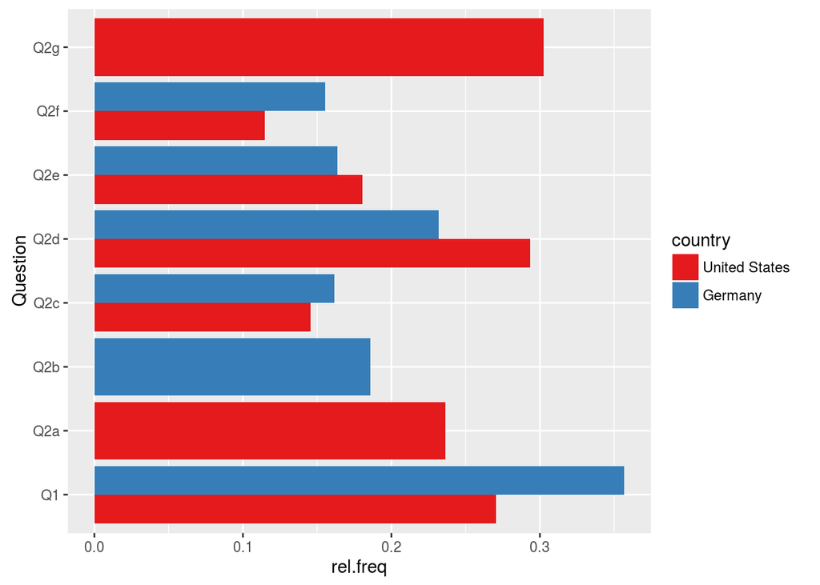

```r
AllGood_data <- trade %>% select(country, contains('Q')) %>% gather(Question, Answer, -country) %>% group_by(country, Question, Answer) %>% summarise(Total.counts = n()) %>% mutate(rel.freq = Total.counts/sum(Total.counts)) %>% filter( Answer == 'Very good')
allQs_plot <- ggplot(data = AllGood_data, aes(x = Question, y = rel.freq, fill = country)) + geom_bar(stat = 'identity', position = 'dodge')
allQs_plot + coord_flip() + scale_fill_brewer(palette = 'Set1')
```

Next we separate for the different answers, ‘Very good’, ‘Somewhat good’, ‘Somewhat bad’, ‘Very bad’, ‘DK/Refused’.

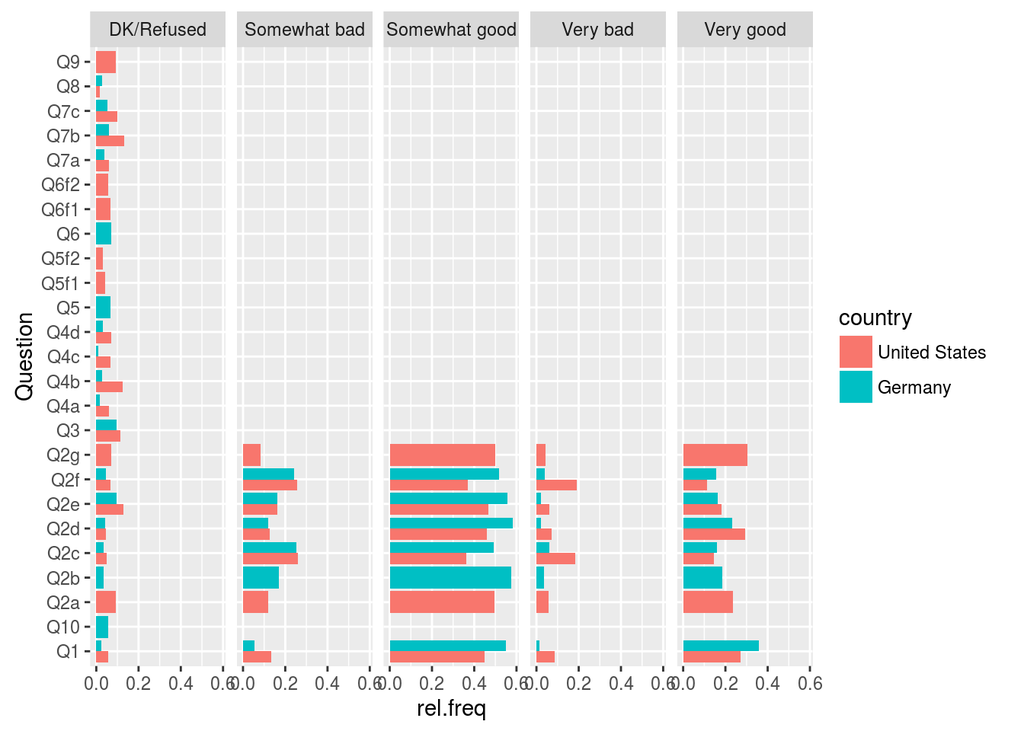

```r
sel_answers = c('Very good', 'Somewhat good', 'Somewhat bad', 'Very bad', 'DK/Refused')
trade_data <- trade %>% select(country, contains('Q')) %>% gather(Question, Answer, -country) %>%  group_by(country, Question, Answer) %>% summarise(Total.counts = n()) %>% mutate(rel.freq = Total.counts/sum(Total.counts)) %>% filter(Answer %in% sel_answers)
allQs_plot_sep <- ggplot(data = na.omit(trade_data), aes(x = Question, y = rel.freq, fill = country)) + geom_bar(stat = 'identity', position = 'dodge') + facet_grid(~ Answer) + coord_flip()
allQs_plot_sep
```

#### Sentiment by demographic

Separating question via income level. There is a factor coloumn in the dataset

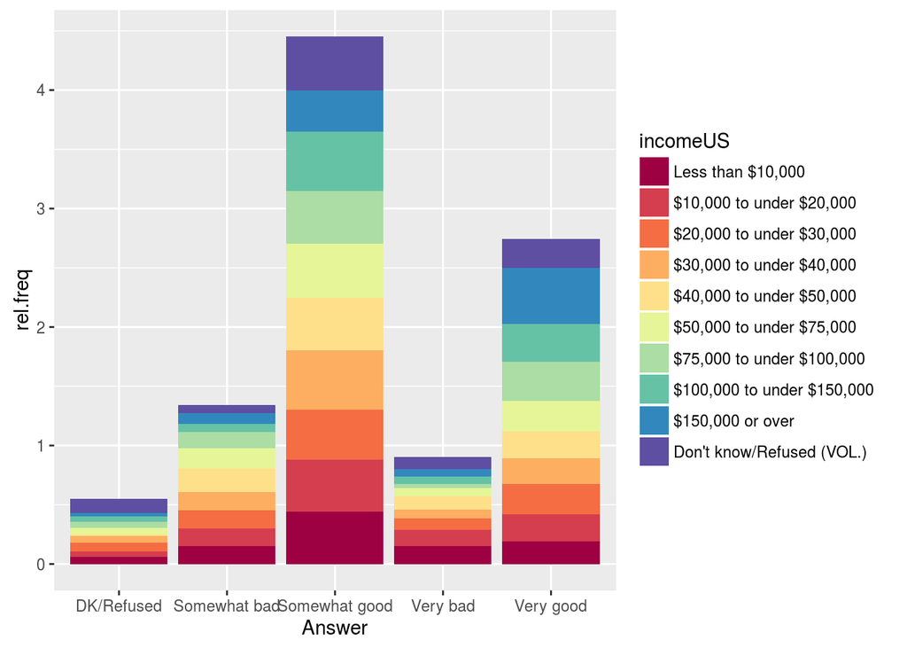

```r
q.income_data <- trade %>% filter(country == 'United States') %>% select(incomeUS, Q1) %>% gather(Question, Answer, -incomeUS) %>% group_by(incomeUS,Question, Answer ) %>% summarise(Total.counts = n()) %>% mutate(rel.freq = Total.counts/sum(Total.counts))
q.income.plot = ggplot(data = na.omit(q.income_data), aes(x = Answer, y = rel.freq, fill = incomeUS)) + geom_bar(stat = 'identity')
q.income.plot  + scale_fill_brewer(palette = 'Spectral')
```